# Instalación de un motor trifásico para una cinta transportadora

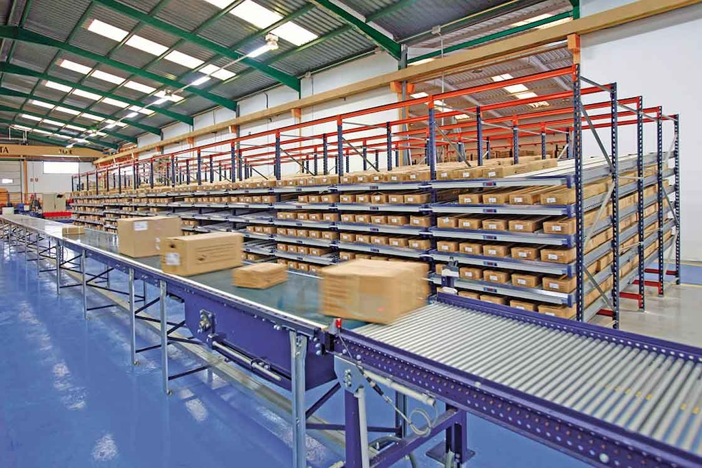

## 1. Introducción

Una fábrica quiere alimentar un **motor trifásico** que mueve una cinta transportadora.

El proyecto consiste en diseñar progresivamente la instalación eléctrica necesaria para alimentar y proteger este motor, tomando decisiones técnicas y justificándolas a partir de la reglamentación correspondiente.

### Norma de referencia

Para este proyecto utilizaremos como referencia la:

**AEA 90364 – Parte 7 – Sección 771: Instalaciones en lugares y locales unitarios – Marzo de 2006.**

Esta sección contiene requisitos y criterios para el diseño de instalaciones eléctricas de baja tensión. Aunque está orientada principalmente a viviendas, oficinas y locales unitarios, la utilizaremos como **referencia normativa para este proyecto didáctico**, aplicando los requisitos que resulten pertinentes a la instalación que vamos a diseñar.

La norma será el documento principal de consulta durante el proyecto. Más adelante deberán aprender a localizar en ella la información necesaria para justificar sus decisiones.

**No es necesario leer toda la norma de principio a fin.** En cada etapa del proyecto se indicará qué aspecto de la instalación deben resolver y qué información deberán buscar.

## 2. Esquema físico

La instalación estará formada inicialmente por dos tramos:

- **Tramo A:** desde el tablero principal de la fábrica hasta el tablero de la máquina.
- **Tramo B:** desde el tablero de la máquina hasta el motor.

[figure not shown]

Los valores de las distancias **A** y **B**, junto con las características del motor y otros datos necesarios, se proporcionarán progresivamente durante el proyecto.

## 3. Conocimientos previos

Antes de comenzar con el diseño de la instalación, prepará una explicación breve de los siguientes temas.

Lo importante no es escribir un texto extenso, sino **comprenderlos y poder explicarlos oralmente al profesor**.

- Explicar el triángulo de potencias: **P, Q y S**, y el significado de **cos φ**.
- Explicar conceptualmente **corriente y tensión de línea y de fase** en una carga trifásica. Indicar además cuáles son las tensiones habituales de una instalación trifásica en Argentina.
- Explicar qué representa el **rendimiento η** que aparece en la placa de un motor.
- Explicar qué es el **factor de servicio** de un motor.

Una vez comprendidos estos conceptos y realizada la exposición, comenzaremos con el diseño de la instalación.